# Assignment 6

## 4.2 New Model

Based off of your findings in the previous section, make changes to the variables, the functional form, etc.

will try multiple attempts to fix assumptions

### 4.2.1 normal model

model1 <- lm(sale_def ~., data = prprice) summary(model1) plot(model1) summary(gvlma(model1))

adjusted r^2 = .5438, no assumption satisfied on gvlma, dist_lake not significant, outliers of 7 and 37

###model without dist_lake nolakemodel <- lm(sale_def ~ bed + bath + area + area_heated + dist_cbd + pool, data = prprice) summary(nolakemodel) plot(nolakemodel) summary(gvlma(nolakemodel))

adjusted r^2 = .5443, no assumptions satisfied

nolakemodel1 <- lm(sale_def ~ bed + bath + area + area_heated + dist_cbd + pool, data = prprice[-c(7,37),]) summary(nolakemodel1) plot(nolakemodel1)

summary(gvlma(nolakemodel1))

### 4.2.3 adjusted r^2 = .6894, pool teetering on significance, only heteroskedasticity is acceptable on gvlma

### 4.2.4 log of y

logmodel <- lm(log(sale_def) ~ bed + bath + area + area_heated + dist_cbd + pool, data = prprice) summary(logmodel) plot(logmodel) summary(gvlma(logmodel))

adjusted r^2 = .7393, all significant, only heteroskedasticity is acceptable on gvlma

### 4.2.5 sqrt of y

sqrtmodel <- lm(sqrt(sale_def) ~ bed + bath + area + area_heated + dist_cbd + pool, data = prprice[-c(7),]) summary(sqrtmodel) plot(sqrtmodel) summary(gvlma(sqrtmodel))

no assumptions satisfied but adjusted r^2 = .7895

### 4.2.6 combine sales and area

SAmodel <- lm((sale_def/area) ~ bed + bath + area_heated + dist_cbd + dist_lakes + pool, data = prprice) summary(SAmodel) plot(SAmodel) summary(gvlma(SAmodel))

homoskedastic and link function satisfied, however adj r^2 = .2698, dist_cbd and pool not significant.

### 4.2.7 log combined sales and area y

logSAmodel <- lm(log(sale_def/area) ~ bed + bath + area_heated + dist_cbd + (dist_lakes) + pool, data = prprice) summary(logSAmodel) plot(logSAmodel) summary(gvlma(logSAmodel))

adj r^2 = .2467, heteroskedasticity sat, dist_cbd and pool not significant

### 4.2.8 log combined sales and area, log all IVs

logSAallmodel <- lm(log(sale_def/area) ~ log(bed) + log(bath) + log(area_heated) + log(dist_cbd) + log(dist_lakes) + (pool), data = prprice) summary(logSAallmodel) plot(logSAallmodel) summary(gvlma(logSAallmodel))

adj r^2 = .2704, pool not significant (not logged), heterosked and link function satisfied.

### 4.2.9 sqrt combined sales and area

sqrtSAmodel <- lm(sqrt(sale_def/area) ~ bed + bath + area_heated + dist_cbd + (dist_lakes) + pool, data = prprice) summary(sqrtSAmodel) plot(sqrtSAmodel) summary(gvlma(sqrtSAmodel))

adj r^2 = .2697, dist_cbd and pool not significant, only heteroskedasticity satisfied

### 4.2.10 boxcox-transformation

powermodel <- lm((sale_def^(-.33)) ~ bath + area_heated + dist_cbd + pool, data = prprice[-c(37,329),]) summary(powermodel) plot(powermodel) summary(gvlma(powermodel))

stepAIC(powermodel, direction = “backward”)

hist(prprice$sale_def^-.33) ### highest I could get adj r^2 = .6678, no assumptions satisfied

### 4.2.11 Researched this online to try and figure it out

boxCox(model1, family=“yjPower”, plotit = TRUE) transale_def <- yjPower(prprice$sale_def, .22)

boxcoxmodel <- lm((sale_def^(.22)) ~ bed + bath + (area_heated) + (area) + (dist_cbd) + pool, data = prprice[-c(7),]) summary(boxcoxmodel) plot(boxcoxmodel) summary(gvlma(boxcoxmodel)) ### adj r^2 of .7843, hetero and link function satisfied.

hist(prprice$sale_def^.22)

### 4.2.12

boxTidwell((sale_def) ~ bed + bath + area + area_heated + dist_cbd, other.x=~ pool, data = prprice[-c(7),])

BoxTidmodel <- lm(sale_def ~ I(bed^(-8.65)) + I(bath^(3.72)) + I(area^(10.09)) + I(area_heated^(20.75)) + dist_cbd, data = prprice[-c(7),]) summary(BoxTidmodel) plot(BoxTidmodel)

### 4.2.13 adj r^2 of .8866 but the plots are wonky as can be. Won’t give the gvlma.

#I can’t get anything to budge with the full gvlma satisfied.

prprice1 <- data.frame(prprice) prprice1$sareaheated <- (prprice$sale_def/prprice$area_heated) prprice1$logsareaheated <- log(prprice$sale_def/prprice$area_heated) prprice1$sqrtareaheated <- sqrt(prprice$sale_def/prprice$area_heated) prprice1$salearea <- (prprice$sale_def/prprice$area) hist(prprice1$salearea) prprice1$logsalearea <- (log(prprice$sale_def/prprice$area)) hist(prprice1$logsalearea) prprice1$sqrtsalearea <- (sqrt(prprice$sale_def/prprice$area)) hist(prprice1$sqrtsalearea) prprice1$logsarea_heated <- (log(prprice$area_heated)) hist(prprice1$logsarea_heated) prprice1$sqrtarea_heated <- (sqrt(prprice$area_heated)) hist(prprice1$sqrtarea_heated) prprice1$logdist_lakes <- (log(prprice$dist_lakes)) hist(prprice1$logdist_lakes) prprice1$sqrtdist_lakes<- (sqrt(prprice$dist_lakes)) hist(prprice1$sqrtdist_lakes) prprice1$logbath <- (log(prprice$bath)) hist(prprice1$logbath) prprice1$sqrtbath <- (sqrt(prprice$bath)) hist(prprice1$sqrtbath) describe(prprice1) describe(prprice)

^^^^ this was for me to check kurtosis and skew, etc. #################

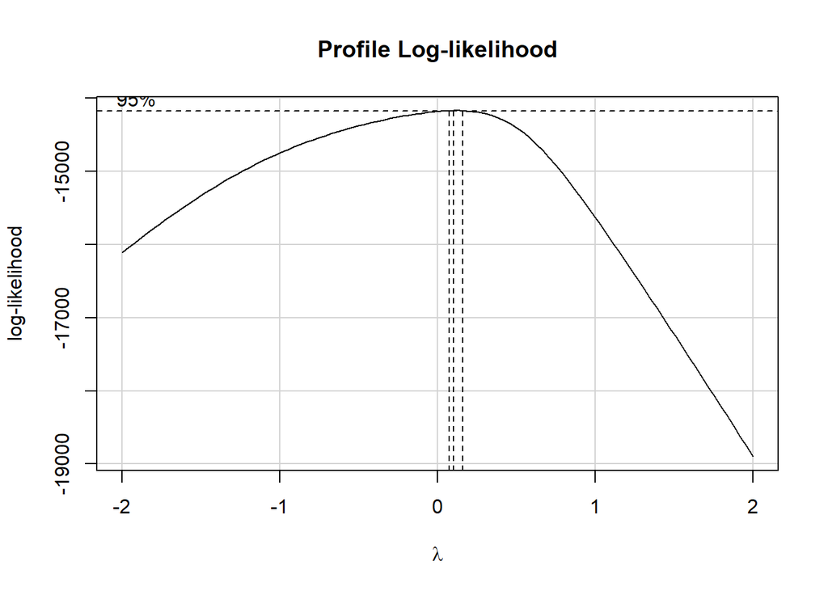

```r
### Researched this online to try and figure it out
boxCox(model1, family="yjPower", plotit = TRUE)
```

```r
transale_def <- yjPower(prprice$sale_def, .22)



boxcoxmodel <- lm((sale_def^(.22)) ~ bed + bath + (area_heated) + (area) + (dist_cbd) + pool, data = prprice[-c(7),])
summary(boxcoxmodel)
```

```
##
## Call:
## lm(formula = (sale_def^(0.22)) ~ bed + bath + (area_heated) +
##     (area) + (dist_cbd) + pool, data = prprice[-c(7), ])
##
## Residuals:
##     Min      1Q  Median      3Q     Max
## -3.6512 -0.5306 -0.0237  0.4839  3.6849
##
## Coefficients:
##               Estimate Std. Error t value Pr(>|t|)
## (Intercept)  1.098e+01  1.384e-01  79.344  < 2e-16 ***
## bed         -2.434e-01  4.842e-02  -5.026 5.93e-07 ***
## bath         4.622e-01  6.736e-02   6.861 1.20e-11 ***
## area_heated  1.573e-03  6.608e-05  23.808  < 2e-16 ***
## area         1.659e-05  4.229e-06   3.923 9.36e-05 ***
## dist_cbd    -2.930e-05  4.674e-06  -6.270 5.39e-10 ***
## pool1        3.966e-01  7.341e-02   5.403 8.20e-08 ***
## ---
## Signif. codes:  0 '***' 0.001 '**' 0.01 '*' 0.05 '.' 0.1 ' ' 1
##
## Residual standard error: 0.8688 on 992 degrees of freedom
## Multiple R-squared:  0.7856, Adjusted R-squared:  0.7843
## F-statistic: 605.6 on 6 and 992 DF,  p-value: < 2.2e-16
```

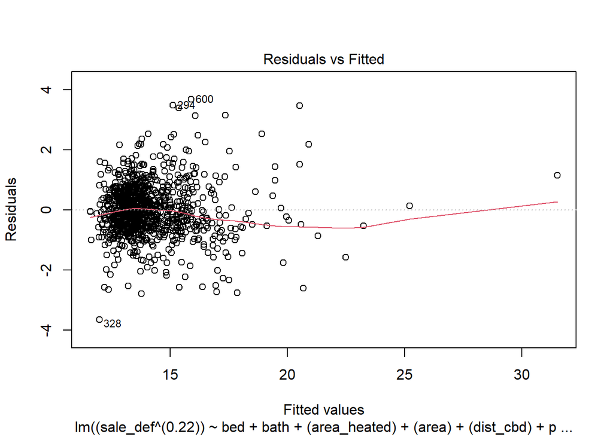

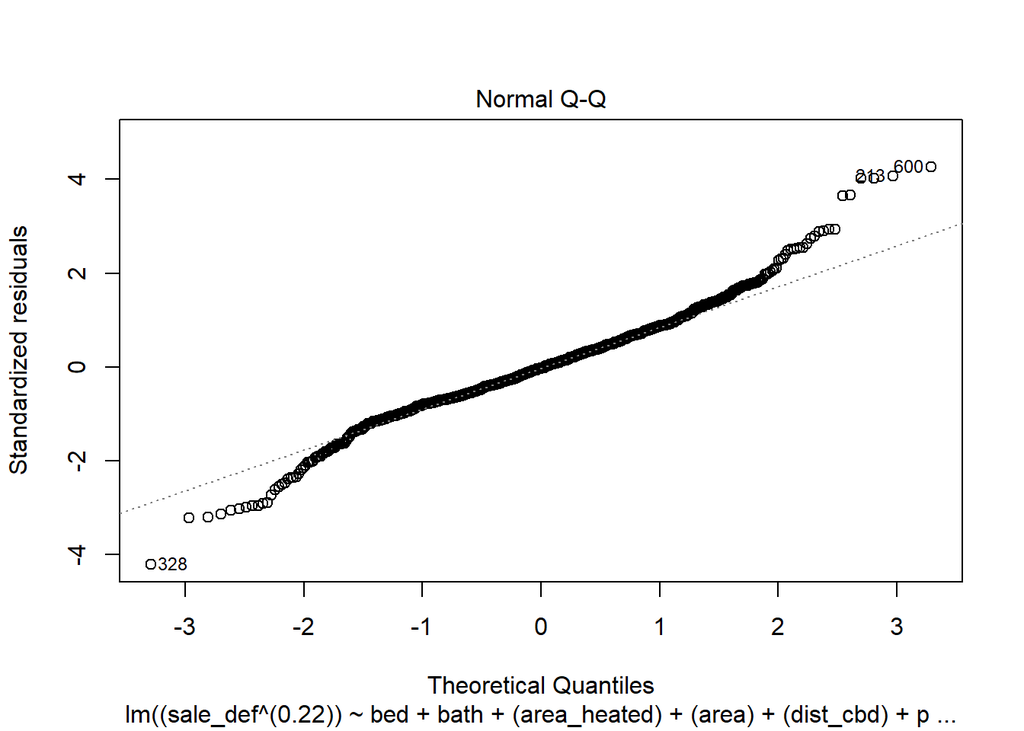

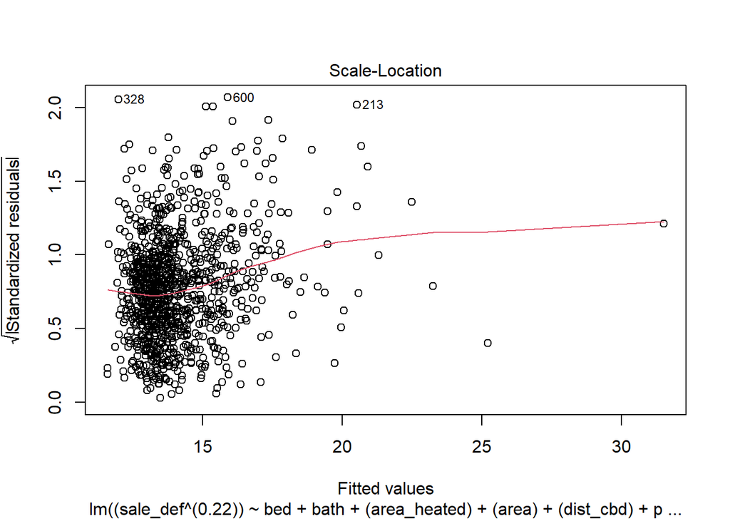

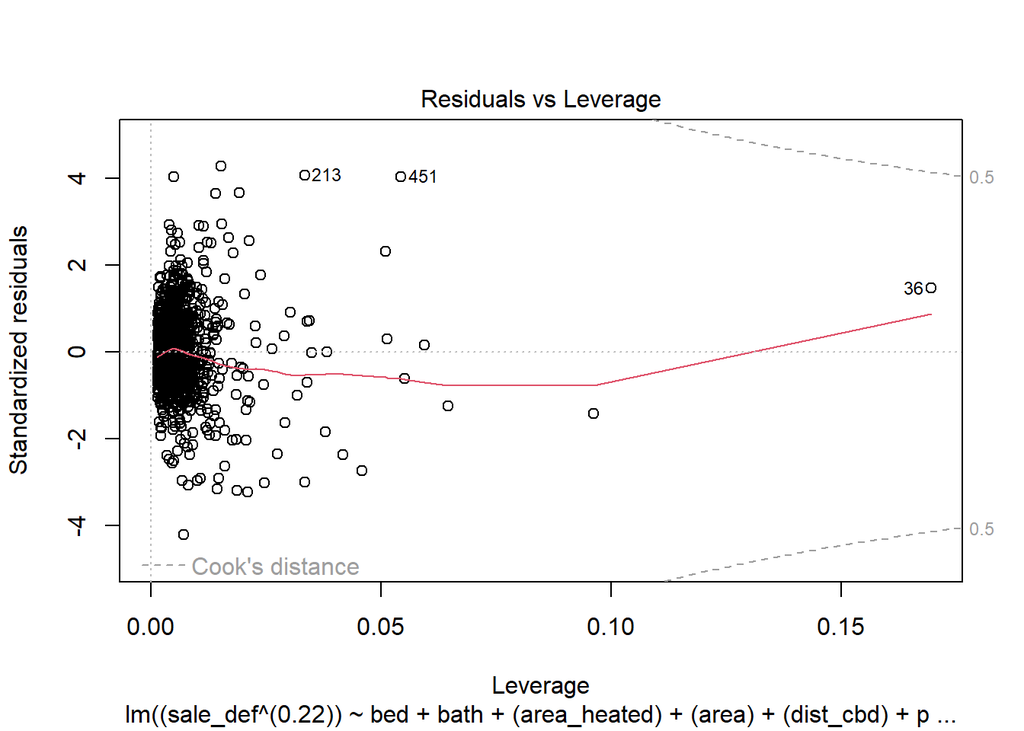

```r
plot(boxcoxmodel)
```

```r
summary(gvlma(boxcoxmodel))
```

```
##
## Call:
## lm(formula = (sale_def^(0.22)) ~ bed + bath + (area_heated) +
##     (area) + (dist_cbd) + pool, data = prprice[-c(7), ])
##
## Residuals:
##     Min      1Q  Median      3Q     Max
## -3.6512 -0.5306 -0.0237  0.4839  3.6849
##
## Coefficients:
##               Estimate Std. Error t value Pr(>|t|)
## (Intercept)  1.098e+01  1.384e-01  79.344  < 2e-16 ***
## bed         -2.434e-01  4.842e-02  -5.026 5.93e-07 ***
## bath         4.622e-01  6.736e-02   6.861 1.20e-11 ***
## area_heated  1.573e-03  6.608e-05  23.808  < 2e-16 ***
## area         1.659e-05  4.229e-06   3.923 9.36e-05 ***
## dist_cbd    -2.930e-05  4.674e-06  -6.270 5.39e-10 ***
## pool1        3.966e-01  7.341e-02   5.403 8.20e-08 ***
## ---
## Signif. codes:  0 '***' 0.001 '**' 0.01 '*' 0.05 '.' 0.1 ' ' 1
##
## Residual standard error: 0.8688 on 992 degrees of freedom
## Multiple R-squared:  0.7856, Adjusted R-squared:  0.7843
## F-statistic: 605.6 on 6 and 992 DF,  p-value: < 2.2e-16
##
##
## ASSESSMENT OF THE LINEAR MODEL ASSUMPTIONS
## USING THE GLOBAL TEST ON 4 DEGREES-OF-FREEDOM:
## Level of Significance =  0.05
##
## Call:
##  gvlma(x = boxcoxmodel)
##
##                       Value p-value                   Decision
## Global Stat        161.0949 0.00000 Assumptions NOT satisfied!
## Skewness             6.1603 0.01307 Assumptions NOT satisfied!
## Kurtosis           153.3465 0.00000 Assumptions NOT satisfied!
## Link Function        0.1861 0.66622    Assumptions acceptable.
## Heteroscedasticity   1.4021 0.23638    Assumptions acceptable.
```

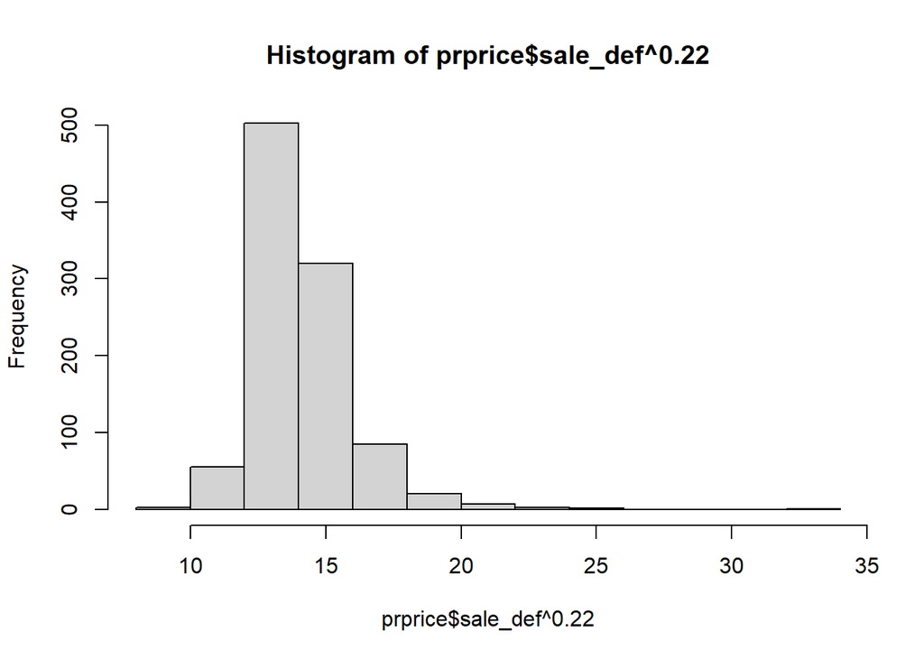

```r
### adj r^2 of .7843, hetero and link function satisfied.

hist(prprice$sale_def^.22)
```

```r
#######
####
##
#Conclusion, using boxcoxmodel
boxcoxmodel <- lm((sale_def^(.22)) ~ bed + bath + (area_heated) + (area) + (dist_cbd) + pool, data = prprice[-c(7),])
summary(boxcoxmodel)
```

```
##
## Call:
## lm(formula = (sale_def^(0.22)) ~ bed + bath + (area_heated) +
##     (area) + (dist_cbd) + pool, data = prprice[-c(7), ])
##
## Residuals:
##     Min      1Q  Median      3Q     Max
## -3.6512 -0.5306 -0.0237  0.4839  3.6849
##
## Coefficients:
##               Estimate Std. Error t value Pr(>|t|)
## (Intercept)  1.098e+01  1.384e-01  79.344  < 2e-16 ***
## bed         -2.434e-01  4.842e-02  -5.026 5.93e-07 ***
## bath         4.622e-01  6.736e-02   6.861 1.20e-11 ***
## area_heated  1.573e-03  6.608e-05  23.808  < 2e-16 ***
## area         1.659e-05  4.229e-06   3.923 9.36e-05 ***
## dist_cbd    -2.930e-05  4.674e-06  -6.270 5.39e-10 ***
## pool1        3.966e-01  7.341e-02   5.403 8.20e-08 ***
## ---
## Signif. codes:  0 '***' 0.001 '**' 0.01 '*' 0.05 '.' 0.1 ' ' 1
##
## Residual standard error: 0.8688 on 992 degrees of freedom
## Multiple R-squared:  0.7856, Adjusted R-squared:  0.7843
## F-statistic: 605.6 on 6 and 992 DF,  p-value: < 2.2e-16
```

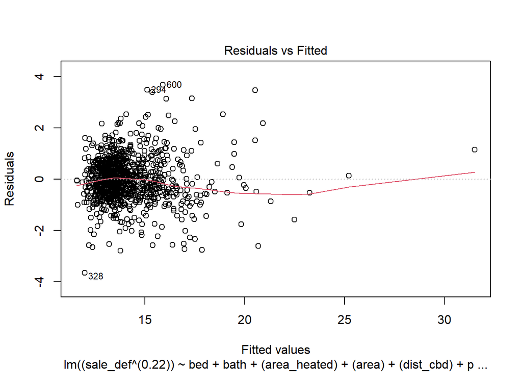

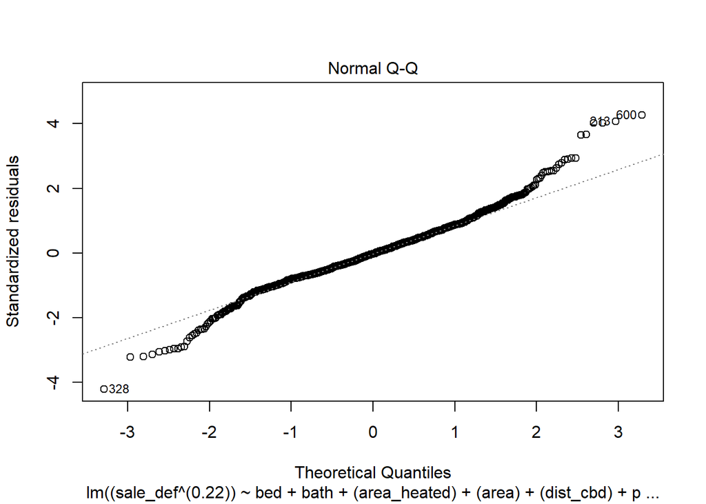

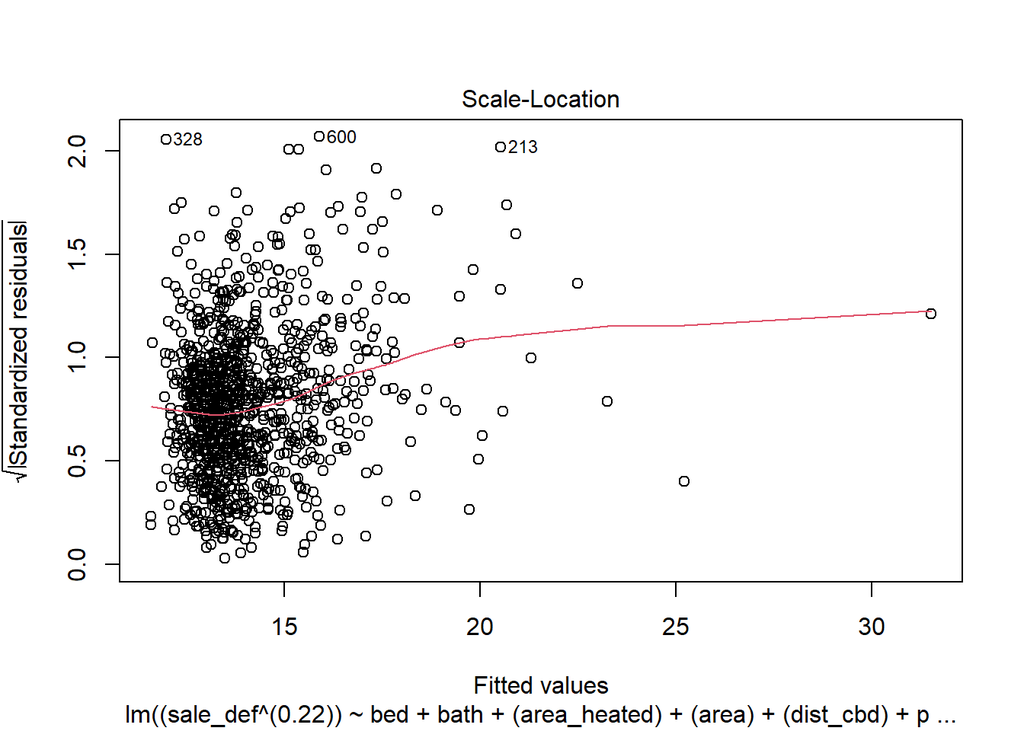

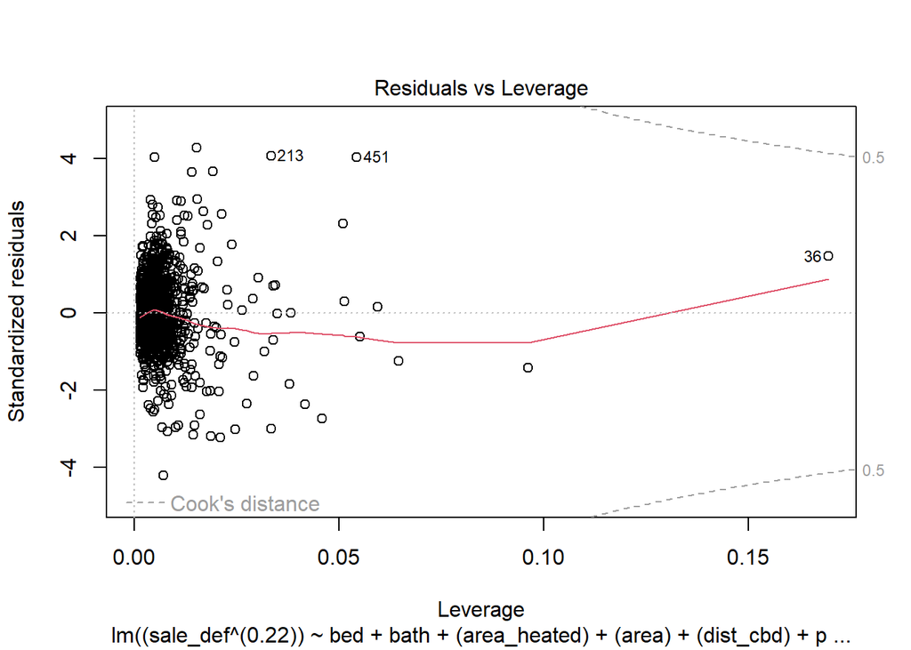

```r
plot(boxcoxmodel)
```

```r
summary(gvlma(boxcoxmodel))
```

```
##
## Call:
## lm(formula = (sale_def^(0.22)) ~ bed + bath + (area_heated) +
##     (area) + (dist_cbd) + pool, data = prprice[-c(7), ])
##
## Residuals:
##     Min      1Q  Median      3Q     Max
## -3.6512 -0.5306 -0.0237  0.4839  3.6849
##
## Coefficients:
##               Estimate Std. Error t value Pr(>|t|)
## (Intercept)  1.098e+01  1.384e-01  79.344  < 2e-16 ***
## bed         -2.434e-01  4.842e-02  -5.026 5.93e-07 ***
## bath         4.622e-01  6.736e-02   6.861 1.20e-11 ***
## area_heated  1.573e-03  6.608e-05  23.808  < 2e-16 ***
## area         1.659e-05  4.229e-06   3.923 9.36e-05 ***
## dist_cbd    -2.930e-05  4.674e-06  -6.270 5.39e-10 ***
## pool1        3.966e-01  7.341e-02   5.403 8.20e-08 ***
## ---
## Signif. codes:  0 '***' 0.001 '**' 0.01 '*' 0.05 '.' 0.1 ' ' 1
##
## Residual standard error: 0.8688 on 992 degrees of freedom
## Multiple R-squared:  0.7856, Adjusted R-squared:  0.7843
## F-statistic: 605.6 on 6 and 992 DF,  p-value: < 2.2e-16
##
##
## ASSESSMENT OF THE LINEAR MODEL ASSUMPTIONS
## USING THE GLOBAL TEST ON 4 DEGREES-OF-FREEDOM:
## Level of Significance =  0.05
##
## Call:
##  gvlma(x = boxcoxmodel)
##
##                       Value p-value                   Decision
## Global Stat        161.0949 0.00000 Assumptions NOT satisfied!
## Skewness             6.1603 0.01307 Assumptions NOT satisfied!
## Kurtosis           153.3465 0.00000 Assumptions NOT satisfied!
## Link Function        0.1861 0.66622    Assumptions acceptable.
## Heteroscedasticity   1.4021 0.23638    Assumptions acceptable.
```

```r
### adj r^2 of .7843, hetero and link function satisfied, normality not satisfied even after using the boxcox transformation.
# After further study, violation of normality may not be significant if both linearity and homoskedasticity are present

# this was HELL
# did you mean FUN?
```

# 5 Prediction

Based on the following inputs, predict the deflated sales price:

- 2 bed
- 2 bath
- area_heated = 1223
- area = 9750
- dist_cbd = 19368
- dist_lakes = 490
- no pool

```r
NewData <-data.frame("bed" = 2, "bath" =2, "area_heated" =1223, "area"=9750, "dist_cbd"=19368, "dist_lakes"=490, "pool"=factor(0))
x <- predict(boxcoxmodel, NewData)

PredictedCost <- (exp(1))^(log(x)/.22)
print(PredictedCost)
```

```
##        1
## 113248.2
```